# BIS 15L Midterm 2

Yutong Ji

2022-02-20

```r
library(tidyverse)
library(ggthemes)
```

```r
options(scipen=999)
```

## Instructions

Answer the following questions and complete the exercises in RMarkdown. Please embed all of your code and push your final work to your repository. Your code should be organized, clean, and run free from errors. Be sure to **add your name** to the author header above. You may use any resources to answer these questions (including each other), but you may not post questions to Open Stacks or external help sites. There are 10 total questions.

Make sure to use the formatting conventions of RMarkdown to make your report neat and clean! Your plots should use consistent aesthetics throughout.

This exam is due by **12:00p on Tuesday, February 22**.

## Gapminder

For this assignment, we are going to use data from [gapminder](https://www.gapminder.org/). Gapminder includes information about economics, population, social issues, and life expectancy from countries all over the world. We will use three data sets, so please load all three as separate objects.

1. population_total.csv

```r
pop_total <- readr::read_csv("data/population_total.csv")
summary(pop_total)
```

[output not shown]

[output cut: 652 more lines]

[output not shown]

2. income_per_person_gdppercapita_ppp_inflation_adjusted.csv

```r
income <- readr::read_csv("data/income_per_person_gdppercapita_ppp_inflation_adjusted.csv")
summary(income)
```

[output not shown]

[output cut: 344 more lines]

[output not shown]

3. life_expectancy_years.csv

```r
life_exp <- readr::read_csv("data/life_expectancy_years.csv")
summary(life_exp)
```

[output not shown]

[output cut: 553 more lines]

[output not shown]

1. (3 points) Once you have an idea of the structure of the data, please make each data set tidy (hint: think back to pivots) and store them as new objects. You will need both the original (wide) and tidy (long) data!

```r
pop_total_tidy <- pop_total %>%
  pivot_longer(-country,
               names_to = "year",
               values_to = "population")
income_tidy <- income %>%
  pivot_longer(-country,
               names_to = "year",
               values_to = "income")
life_exp_tidy <- life_exp %>%
  pivot_longer(-country,
               names_to = "year",
               values_to = "life_expectancy")
```

2. (1 point) How many different countries are represented in the data? Provide the total number and their names. Since each data set includes different numbers of countries, you will need to do this for each one.

```r
pop_total_tidy %>%
  distinct(country)
```

```
## # A tibble: 195 x 1
##    country
##    <chr>
##  1 Afghanistan
##  2 Albania
##  3 Algeria
##  4 Andorra
##  5 Angola
##  6 Antigua and Barbuda
##  7 Argentina
##  8 Armenia
##  9 Australia
## 10 Austria
## # ... with 185 more rows
```

```r
income_tidy %>%
  distinct(country)
```

```
## # A tibble: 193 x 1
##    country
##    <chr>
##  1 Afghanistan
##  2 Albania
##  3 Algeria
##  4 Andorra
##  5 Angola
##  6 Antigua and Barbuda
##  7 Argentina
##  8 Armenia
##  9 Australia
## 10 Austria
## # ... with 183 more rows
```

```r
life_exp_tidy %>%
  distinct(country)
```

```
## # A tibble: 187 x 1
##    country
##    <chr>
##  1 Afghanistan
##  2 Albania
##  3 Algeria
##  4 Andorra
##  5 Angola
##  6 Antigua and Barbuda
##  7 Argentina
##  8 Armenia
##  9 Australia
## 10 Austria
## # ... with 177 more rows
```

## Life Expectancy

```r
life_exp_tidy %>%
  filter(between(year, 1920, 2020)) %>%
  group_by(country)%>%
  summarise(mean_life_exp=mean(life_expectancy, na.rm=T))%>%
  arrange(desc(mean_life_exp))
```

```
## # A tibble: 187 x 2
##    country     mean_life_exp
##    <chr>               <dbl>
##  1 Andorra              79.8
##  2 Sweden               73.5
##  3 Norway               73.2
##  4 Netherlands          73.0
##  5 Dominica             73.0
##  6 Iceland              72.9
##  7 Australia            72.7
##  8 Switzerland          72.7
##  9 Denmark              71.9
## 10 Canada               71.8
## # ... with 177 more rows
```

4. (3 points) Although we can see which country has the highest life expectancy for the past 100 years, we don’t know which countries have changed the most. What are the top 5 countries that have experienced the biggest improvement in life expectancy between 1920-2020?

```r
life_exp_tidy %>%
  filter(year == "1920"| year == "2020") %>%
  group_by(country)%>%
  summarise(change_life_exp=max(life_expectancy)-min(life_expectancy))%>%
  arrange(desc(change_life_exp))
```

```
## # A tibble: 187 x 2
##    country         change_life_exp
##    <chr>                     <dbl>
##  1 Kuwait                     56.8
##  2 Kyrgyz Republic            56.5
##  3 Turkmenistan               55.3
##  4 South Korea                55
##  5 Tajikistan                 54.3
##  6 Nicaragua                  54.2
##  7 Kazakhstan                 53.8
##  8 Russia                     52.2
##  9 Israel                     51.4
## 10 Iran                       51.2
## # ... with 177 more rows
```

5. (3 points) Make a plot that shows the change over the past 100 years for the country with the biggest improvement in life expectancy. Be sure to add appropriate aesthetics to make the plot clean and clear. Once you have made the plot, do a little internet searching and see if you can discover what historical event may have contributed to this remarkable change.

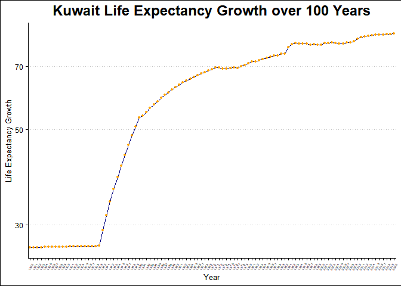

```r
p <- life_exp_tidy %>%
  filter(between(year, 1920, 2020), country == "Kuwait") %>%
  group_by(country) %>%
  ggplot(aes(x=year, y=life_expectancy, group= country))+
  geom_line(color= "navyblue")+
  geom_point(size=1, color= "orange")+
  scale_y_log10()
p+theme_clean()+
  theme(plot.title = element_text(size = rel(1.5), hjust = 0.5), axis.text.x = element_text(angle = 60, hjust = 1, size=4))+
  labs(title = "Kuwait Life Expectancy Growth over 100 Years",
       x = "Year",
       y = "Life Expectancy Growth")
```

## Population Growth

6. (3 points) Which 5 countries have had the highest population growth over the past 100 years (1920-2020)?

```r
pop_total_tidy %>%
  filter(year == "1920"| year == "2020") %>%
  group_by(country)%>%
  summarise(pop_growth=max(population)-min(population))%>%
  arrange(desc(pop_growth))%>%
  head(pop_growth, n=5)
```

```
## # A tibble: 5 x 2
##   country       pop_growth
##   <chr>              <dbl>
## 1 India         1063000000
## 2 China          968000000
## 3 Indonesia      226700000
## 4 United States  220000000
## 5 Pakistan       199300000
```

7. (4 points) Produce a plot that shows the 5 countries that have had the highest population growth over the past 100 years (1920-2020). Which countries appear to have had exponential growth?

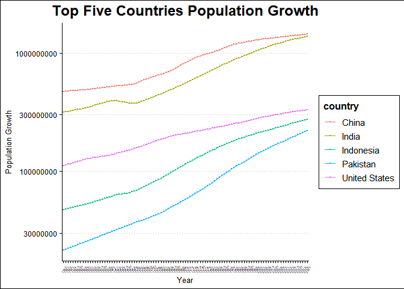

```r
p1 <- pop_total_tidy %>%
  filter(between(year, 1920, 2020), country == "India"|country == "China"|country == "Indonesia"|country == "United States"|country == "Pakistan") %>%
  group_by(country)%>%
  ggplot(aes(x=year, y=population, group=country, color=country))+
  geom_line()+
  geom_point(size=0.5)+
  scale_y_log10()
p1+theme_clean()+
  theme(plot.title = element_text(size = rel(1.5), hjust = 0.5), axis.text.x = element_text(angle = 60, hjust = 1, size=3.5))+
  labs(title = "Top Five Countries Population Growth",
       x = "Year",
       y = "Population Growth")
```

## Income

The units used for income are gross domestic product per person adjusted for differences in purchasing power in international dollars.

8. (4 points) As in the previous questions, which countries have experienced the biggest growth in per person GDP. Show this as a table and then plot the changes for the top 5 countries. With a bit of research, you should be able to explain the dramatic downturns of the wealthiest economies that occurred during the 1980’s.

```r
income_tidy %>%
  filter(year == "1920"| year == "2020") %>%
  group_by(country)%>%
  summarise(gdp_growth=max(income)-min(income))%>%
  arrange(desc(gdp_growth))
```

```
## # A tibble: 193 x 2
##    country              gdp_growth
##    <chr>                     <dbl>
##  1 Qatar                    113700
##  2 Luxembourg                89370
##  3 Singapore                 88060
##  4 Brunei                    72970
##  5 Ireland                   68930
##  6 United Arab Emirates      63210
##  7 Kuwait                    61950
##  8 Norway                    58540
##  9 Monaco                    55370
## 10 San Marino                54620
## # ... with 183 more rows
```

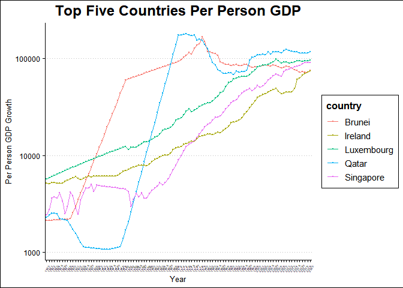

```r
p3 <- income_tidy %>%
  filter(between(year, 1920, 2020), country == "Qatar"|country == "Luxembourg"|country == "Singapore"|country == "Brunei"|country == "Ireland") %>%
  group_by(country)%>%
  ggplot(aes(x=year, y=income, group=country, color=country))+
  geom_line()+
  geom_point(size=0.5)+
  scale_y_log10()
p3+theme_clean()+
  theme(plot.title = element_text(size = rel(1.5), hjust = 0.5), axis.text.x = element_text(angle = 60, hjust = 1, size=3.5))+
  labs(title = "Top Five Countries Per Person GDP",
       x = "Year",
       y = "Per Person GDP Growth")
```

**The dramatic downturn in Qatar’s economy in 1980s was caused by Irap-Iran War and oil price crush.**

9. (3 points) Create three new objects that restrict each data set (life expectancy, population, income) to the years 1920-2020. Hint: I suggest doing this with the long form of your data. Once this is done, merge all three data sets using the code I provide below. You may need to adjust the code depending on how you have named your objects. I called mine `life_expectancy_100`, `population_100`, and `income_100`. For some of you, learning these `joins` will be important for your project.

```r
life_exp_100 <- life_exp_tidy %>%
  filter(between(year, 1920, 2020))
pop_total_100 <- pop_total_tidy %>%
  filter(between(year, 1920, 2020))
income_100 <- income_tidy %>%
  filter(between(year, 1920, 2020))
gapminder_join <- inner_join(life_exp_100, pop_total_100, by= c("country", "year"))
gapminder_join <- inner_join(gapminder_join, income_100, by= c("country", "year"))
gapminder_join
```

```
## # A tibble: 18,887 x 5
##    country     year  life_expectancy population income
##    <chr>       <chr>           <dbl>      <dbl>  <dbl>
##  1 Afghanistan 1920             30.6   10600000   1490
##  2 Afghanistan 1921             30.7   10500000   1520
##  3 Afghanistan 1922             30.8   10300000   1550
##  4 Afghanistan 1923             30.8    9710000   1570
##  5 Afghanistan 1924             30.9    9200000   1600
##  6 Afghanistan 1925             31      8720000   1630
##  7 Afghanistan 1926             31      8260000   1650
##  8 Afghanistan 1927             31.1    7830000   1680
##  9 Afghanistan 1928             31.1    7420000   1710
## 10 Afghanistan 1929             31.2    7100000   1740
## # ... with 18,877 more rows
```

10. (4 points) Use the joined data to perform an analysis of your choice. The analysis should include a comparison between two or more of the variables `life_expectancy`, `population`, or `income.`

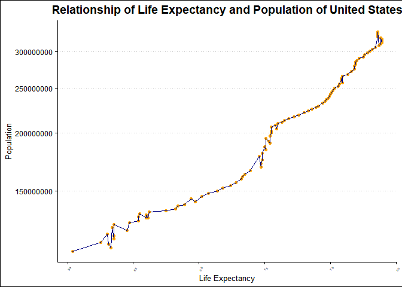

```r
p4 <- gapminder_join %>%
  filter(country == "United States")%>%
  ggplot(aes(x= life_expectancy, y= population)) +
  geom_point(na.rm = T, color= "orange") +
  geom_line(color= "navyblue")+
  scale_y_log10()
p4+theme_clean()+
  theme(plot.title = element_text(size = rel(1.2), hjust = 0.5), axis.text.x = element_text(angle = 60, hjust = 1, size=3.5))+
  labs(title = "Relationship of Life Expectancy and Population of United States",
       x = "Life Expectancy",
       y = "Population")
```

**I am comparing the life expectancy and population of United States over years to see if there is a clear relationship between the two variables. The result suggests that generally, as life expectancy increases, the population also increase.**